# Project: Investigate the TMDb movie dataset

- Introduction
- Data Wrangling
- Exploratory Data Analysis
- Conclusions

## Introduction

> This dataset contains information about thousands of movies collected from TMDb.

> **Notes:**
> - Certain columns, like ‘cast’and ‘genres’, contain multiple values separated by pipe (|) characters.
> - There are some odd characters in the ‘cast’ column. I am leaving them as is.
> - The final two columns ending with “_adj” show the budget and revenue of the associated movie in terms of 2010 dollars, accounting for inflation over time.

> A lot of insight can be garnered from this dataset and we will go about exploring some of these insights in this report. Here are some questions that I am curious to discover the answer to:
> - Top 10 successful movies and their genres.
> - Most popular movie genres and the least popular.
> - Most successful actors.
> - Which month are movies released in the most.
> - Which month are the most profits made.

## First step:

```python
# Import statements I plan to use

import pandas as pd
import numpy as np
import matplotlib.pyplot as plt
import seaborn as sns
from datetime import datetime
% matplotlib inline
```

## Data Wrangling

> In this section of the report, I will load in the data, check for cleanliness, and then trim and clean the dataset for analysis.

### General Properties

```python
# Load the data and print out a few lines.
data = pd.read_csv('tmdb-movies.csv')
data.head()
```

|  | id | imdb_id | popularity | budget | revenue | original_title | cast | homepage | director | tagline | ... | overview | runtime | genres | production_companies | release_date | vote_count | vote_average | release_year | budget_adj | revenue_adj |
| --- | --- | --- | --- | --- | --- | --- | --- | --- | --- | --- | --- | --- | --- | --- | --- | --- | --- | --- | --- | --- | --- |
| 0 | 135397 | tt0369610 | 32.985763 | 150000000 | 1513528810 | Jurassic World | Chris Pratt\|Bryce Dallas Howard\|Irrfan Khan\|Vi... | http://www.jurassicworld.com/ | Colin Trevorrow | The park is open. | ... | Twenty-two years after the events of Jurassic ... | 124 | Action\|Adventure\|Science Fiction\|Thriller | Universal Studios\|Amblin Entertainment\|Legenda... | 6/9/15 | 5562 | 6.5 | 2015 | 1.379999e+08 | 1.392446e+09 |
| 1 | 76341 | tt1392190 | 28.419936 | 150000000 | 378436354 | Mad Max: Fury Road | Tom Hardy\|Charlize Theron\|Hugh Keays-Byrne\|Nic... | http://www.madmaxmovie.com/ | George Miller | What a Lovely Day. | ... | An apocalyptic story set in the furthest reach... | 120 | Action\|Adventure\|Science Fiction\|Thriller | Village Roadshow Pictures\|Kennedy Miller Produ... | 5/13/15 | 6185 | 7.1 | 2015 | 1.379999e+08 | 3.481613e+08 |
| 2 | 262500 | tt2908446 | 13.112507 | 110000000 | 295238201 | Insurgent | Shailene Woodley\|Theo James\|Kate Winslet\|Ansel... | http://www.thedivergentseries.movie/#insurgent | Robert Schwentke | One Choice Can Destroy You | ... | Beatrice Prior must confront her inner demons ... | 119 | Adventure\|Science Fiction\|Thriller | Summit Entertainment\|Mandeville Films\|Red Wago... | 3/18/15 | 2480 | 6.3 | 2015 | 1.012000e+08 | 2.716190e+08 |
| 3 | 140607 | tt2488496 | 11.173104 | 200000000 | 2068178225 | Star Wars: The Force Awakens | Harrison Ford\|Mark Hamill\|Carrie Fisher\|Adam D... | http://www.starwars.com/films/star-wars-episod... | J.J. Abrams | Every generation has a story. | ... | Thirty years after defeating the Galactic Empi... | 136 | Action\|Adventure\|Science Fiction\|Fantasy | Lucasfilm\|Truenorth Productions\|Bad Robot | 12/15/15 | 5292 | 7.5 | 2015 | 1.839999e+08 | 1.902723e+09 |
| 4 | 168259 | tt2820852 | 9.335014 | 190000000 | 1506249360 | Furious 7 | Vin Diesel\|Paul Walker\|Jason Statham\|Michelle ... | http://www.furious7.com/ | James Wan | Vengeance Hits Home | ... | Deckard Shaw seeks revenge against Dominic Tor... | 137 | Action\|Crime\|Thriller | Universal Pictures\|Original Film\|Media Rights ... | 4/1/15 | 2947 | 7.3 | 2015 | 1.747999e+08 | 1.385749e+09 |

5 rows × 21 columns

```python
data.info()
```

```
<class 'pandas.core.frame.DataFrame'>
RangeIndex: 10866 entries, 0 to 10865
Data columns (total 21 columns):
id                      10866 non-null int64
imdb_id                 10856 non-null object
popularity              10866 non-null float64
budget                  10866 non-null int64
revenue                 10866 non-null int64
original_title          10866 non-null object
cast                    10790 non-null object
homepage                2936 non-null object
director                10822 non-null object
tagline                 8042 non-null object
keywords                9373 non-null object
overview                10862 non-null object
runtime                 10866 non-null int64
genres                  10843 non-null object
production_companies    9836 non-null object
release_date            10866 non-null object
vote_count              10866 non-null int64
vote_average            10866 non-null float64
release_year            10866 non-null int64
budget_adj              10866 non-null float64
revenue_adj             10866 non-null float64
dtypes: float64(4), int64(6), object(11)
memory usage: 1.7+ MB
```

```python
data.shape
```

```
(10866, 21)
```

From this data we conclude that:

- There are 10,866 rows and 21 columns
- There are missing data in 'cast', 'homepage' and 7 more columns
- Columns that are not necessary for our analysis are
  - id
  - imdb_id
  - homepage
  - director
  - tagline
  - keywords
  - overview
  - production companies
  - release_year
  - budget and revenue, I plan to keep budget_adj and revenue_adj because they account for inflation and would prove to be a fairer method of comparison.
- Columns with incorrect data type:
  - release_date - we need to reset it to datetime format
  - Convert the data type of adjusted budget and revenue columns to int instead of float

```python
# Drop the columns that are not needed for this analysis:
dropped = ['id','imdb_id','homepage','director','tagline','keywords','overview','production_companies',
           'release_year','budget','revenue']
data.drop(dropped,axis=1, inplace=True)
```

```python
data.head()
```

|  | popularity | original_title | cast | runtime | genres | release_date | vote_count | vote_average | budget_adj | revenue_adj |
| --- | --- | --- | --- | --- | --- | --- | --- | --- | --- | --- |
| 0 | 32.985763 | Jurassic World | Chris Pratt\|Bryce Dallas Howard\|Irrfan Khan\|Vi... | 124 | Action\|Adventure\|Science Fiction\|Thriller | 6/9/15 | 5562 | 6.5 | 1.379999e+08 | 1.392446e+09 |
| 1 | 28.419936 | Mad Max: Fury Road | Tom Hardy\|Charlize Theron\|Hugh Keays-Byrne\|Nic... | 120 | Action\|Adventure\|Science Fiction\|Thriller | 5/13/15 | 6185 | 7.1 | 1.379999e+08 | 3.481613e+08 |
| 2 | 13.112507 | Insurgent | Shailene Woodley\|Theo James\|Kate Winslet\|Ansel... | 119 | Adventure\|Science Fiction\|Thriller | 3/18/15 | 2480 | 6.3 | 1.012000e+08 | 2.716190e+08 |
| 3 | 11.173104 | Star Wars: The Force Awakens | Harrison Ford\|Mark Hamill\|Carrie Fisher\|Adam D... | 136 | Action\|Adventure\|Science Fiction\|Fantasy | 12/15/15 | 5292 | 7.5 | 1.839999e+08 | 1.902723e+09 |
| 4 | 9.335014 | Furious 7 | Vin Diesel\|Paul Walker\|Jason Statham\|Michelle ... | 137 | Action\|Crime\|Thriller | 4/1/15 | 2947 | 7.3 | 1.747999e+08 | 1.385749e+09 |

```python
data.info()
```

```
<class 'pandas.core.frame.DataFrame'>
RangeIndex: 10866 entries, 0 to 10865
Data columns (total 10 columns):
popularity        10866 non-null float64
original_title    10866 non-null object
cast              10790 non-null object
runtime           10866 non-null int64
genres            10843 non-null object
release_date      10866 non-null object
vote_count        10866 non-null int64
vote_average      10866 non-null float64
budget_adj        10866 non-null float64
revenue_adj       10866 non-null float64
dtypes: float64(4), int64(2), object(4)
memory usage: 849.0+ KB
```

```python
# Convert data types of budget and revenue to int and release_date to datetime:
data['budget_adj'] = data['budget_adj'].astype(int)
data['revenue_adj'] = data['revenue_adj'].astype(int)
data['release_date'] = pd.to_datetime(data['release_date'])
```

```python
data.info()
```

```
<class 'pandas.core.frame.DataFrame'>
RangeIndex: 10866 entries, 0 to 10865
Data columns (total 10 columns):
popularity        10866 non-null float64
original_title    10866 non-null object
cast              10790 non-null object
runtime           10866 non-null int64
genres            10843 non-null object
release_date      10866 non-null datetime64[ns]
vote_count        10866 non-null int64
vote_average      10866 non-null float64
budget_adj        10866 non-null int64
revenue_adj       10866 non-null int64
dtypes: datetime64[ns](1), float64(2), int64(4), object(3)
memory usage: 849.0+ KB
```

```python
# It would be prudent to drop NaN values and duplicated values and that would be
# the last step in cleaning this dataset and then we would go about exploring
data.dropna(inplace=True)
```

```python
sum(data.duplicated())
```

```
1
```

```python
# There is only 1 duplicated row in the dataset. Let's go about getting rid of it.
data.drop_duplicates(keep='first',inplace=True)
```

```python
sum(data.duplicated())
```

```
0
```

```python
data.info()
```

```
<class 'pandas.core.frame.DataFrame'>
Int64Index: 10767 entries, 0 to 10865
Data columns (total 10 columns):
popularity        10767 non-null float64
original_title    10767 non-null object
cast              10767 non-null object
runtime           10767 non-null int64
genres            10767 non-null object
release_date      10767 non-null datetime64[ns]
vote_count        10767 non-null int64
vote_average      10767 non-null float64
budget_adj        10767 non-null int64
revenue_adj       10767 non-null int64
dtypes: datetime64[ns](1), float64(2), int64(4), object(3)
memory usage: 925.3+ KB
```

```python
data.describe()
```

|  | popularity | runtime | vote_count | vote_average | budget_adj | revenue_adj |
| --- | --- | --- | --- | --- | --- | --- |
| count | 10767.000000 | 10767.000000 | 10767.000000 | 10767.000000 | 1.076700e+04 | 1.076700e+04 |
| mean | 0.650924 | 102.413393 | 219.137364 | 5.967549 | 1.770705e+07 | 5.183338e+07 |
| std | 1.003565 | 30.906009 | 577.964702 | 0.931426 | 3.442339e+07 | 1.452125e+08 |
| min | 0.000065 | 0.000000 | 10.000000 | 1.500000 | 0.000000e+00 | 0.000000e+00 |
| 25% | 0.209957 | 90.000000 | 17.000000 | 5.400000 | 0.000000e+00 | 0.000000e+00 |
| 50% | 0.386062 | 99.000000 | 39.000000 | 6.000000 | 0.000000e+00 | 0.000000e+00 |
| 75% | 0.719253 | 112.000000 | 147.000000 | 6.600000 | 2.103337e+07 | 3.432264e+07 |
| max | 32.985763 | 900.000000 | 9767.000000 | 9.200000 | 4.250000e+08 | 2.827124e+09 |

> Now lets get the rows where the value of budget and revenue are 0 so that they don't affect our analysis

```python
cd = data[data['budget_adj'] != 0]
```

```python
cd = cd[cd['revenue_adj'] != 0]
```

```python
cd.shape
```

```
(3849, 10)
```

> Everything seems to be in order now. columns have the correct data types, we dropped missing and duplicated values and columns that are not relevant to our analysis.

## Exploratory Data Analysis

```python
cd.describe()
```

|  | popularity | runtime | vote_count | vote_average | budget_adj | revenue_adj |
| --- | --- | --- | --- | --- | --- | --- |
| count | 3849.000000 | 3849.000000 | 3849.000000 | 3849.000000 | 3.849000e+03 | 3.849000e+03 |
| mean | 1.192836 | 109.233827 | 528.375682 | 6.168823 | 4.429470e+07 | 1.372342e+08 |
| std | 1.475679 | 19.924230 | 880.340064 | 0.794596 | 4.481257e+07 | 2.162000e+08 |
| min | 0.001117 | 15.000000 | 10.000000 | 2.200000 | 1.000000e+00 | 2.000000e+00 |
| 25% | 0.463155 | 96.000000 | 71.000000 | 5.700000 | 1.316623e+07 | 1.843023e+07 |
| 50% | 0.798582 | 106.000000 | 205.000000 | 6.200000 | 3.005030e+07 | 6.181393e+07 |
| 75% | 1.374300 | 119.000000 | 581.000000 | 6.700000 | 6.076720e+07 | 1.634115e+08 |
| max | 32.985763 | 338.000000 | 9767.000000 | 8.400000 | 4.250000e+08 | 2.827124e+09 |

> This shows a quick overview of the numerical data here. The average runtime, vote count, budget and revenue and gives an idea about what one might expect during further analysis

> Dropping the NaN and 0 values seems to have made an impact on the brief statistics shown here

### What are the top 10 successful movies and their genres?

```python
# We can do so through either the popularity rating or revenue or profit.
# Let's add the profit column to the dataset to spice things up.

# The insert function's first argument is an index which specifies the location of the column,
# second argument takes the name of the new column...
# last, calculates the values for the column

# To simplify things, we assume that: profit = revenue - budget
cd.insert(10, 'profit_adj', cd['revenue_adj'] - cd['budget_adj'])

# let's make sure that the data type is int
cd['profit_adj'] = cd['profit_adj'].astype(int)

# Taking a glimpse!
cd.head()
```

|  | popularity | original_title | cast | runtime | genres | release_date | vote_count | vote_average | budget_adj | revenue_adj | profit_adj |
| --- | --- | --- | --- | --- | --- | --- | --- | --- | --- | --- | --- |
| 0 | 32.985763 | Jurassic World | Chris Pratt\|Bryce Dallas Howard\|Irrfan Khan\|Vi... | 124 | Action\|Adventure\|Science Fiction\|Thriller | 2015-06-09 | 5562 | 6.5 | 137999939 | 1392445892 | 1254445953 |
| 1 | 28.419936 | Mad Max: Fury Road | Tom Hardy\|Charlize Theron\|Hugh Keays-Byrne\|Nic... | 120 | Action\|Adventure\|Science Fiction\|Thriller | 2015-05-13 | 6185 | 7.1 | 137999939 | 348161292 | 210161353 |
| 2 | 13.112507 | Insurgent | Shailene Woodley\|Theo James\|Kate Winslet\|Ansel... | 119 | Adventure\|Science Fiction\|Thriller | 2015-03-18 | 2480 | 6.3 | 101199955 | 271619025 | 170419070 |
| 3 | 11.173104 | Star Wars: The Force Awakens | Harrison Ford\|Mark Hamill\|Carrie Fisher\|Adam D... | 136 | Action\|Adventure\|Science Fiction\|Fantasy | 2015-12-15 | 5292 | 7.5 | 183999919 | 1902723129 | 1718723210 |
| 4 | 9.335014 | Furious 7 | Vin Diesel\|Paul Walker\|Jason Statham\|Michelle ... | 137 | Action\|Crime\|Thriller | 2015-04-01 | 2947 | 7.3 | 174799923 | 1385748801 | 1210948878 |

```python
# Let's sort by profits made from most profitable to least:
cd.sort_values("profit_adj",axis=0,ascending=False,inplace=True)
```

```python
cd.head(10)
```

|  | popularity | original_title | cast | runtime | genres | release_date | vote_count | vote_average | budget_adj | revenue_adj | profit_adj |
| --- | --- | --- | --- | --- | --- | --- | --- | --- | --- | --- | --- |
| 1329 | 12.037933 | Star Wars | Mark Hamill\|Harrison Ford\|Carrie Fisher\|Peter ... | 121 | Adventure\|Action\|Science Fiction | 1977-03-20 | 4428 | 7.9 | 39575591 | 2789712242 | 2750136651 |
| 1386 | 9.432768 | Avatar | Sam Worthington\|Zoe Saldana\|Sigourney Weaver\|S... | 162 | Action\|Adventure\|Fantasy\|Science Fiction | 2009-12-10 | 8458 | 7.1 | 240886902 | 2827123750 | 2586236848 |
| 5231 | 4.355219 | Titanic | Kate Winslet\|Leonardo DiCaprio\|Frances Fisher\|... | 194 | Drama\|Romance\|Thriller | 1997-11-18 | 4654 | 7.3 | 271692064 | 2506405735 | 2234713671 |
| 10594 | 2.010733 | The Exorcist | Linda Blair\|Max von Sydow\|Ellen Burstyn\|Jason ... | 122 | Drama\|Horror\|Thriller | 1973-12-26 | 1113 | 7.2 | 39289276 | 2167324901 | 2128035625 |
| 9806 | 2.563191 | Jaws | Roy Scheider\|Robert Shaw\|Richard Dreyfuss\|Lorr... | 124 | Horror\|Thriller\|Adventure | 1975-06-18 | 1415 | 7.3 | 28362748 | 1907005841 | 1878643093 |
| 8889 | 2.900556 | E.T. the Extra-Terrestrial | Henry Thomas\|Drew Barrymore\|Robert MacNaughton... | 115 | Science Fiction\|Adventure\|Family\|Fantasy | 1982-04-03 | 1830 | 7.2 | 23726245 | 1791694309 | 1767968064 |
| 3 | 11.173104 | Star Wars: The Force Awakens | Harrison Ford\|Mark Hamill\|Carrie Fisher\|Adam D... | 136 | Action\|Adventure\|Science Fiction\|Fantasy | 2015-12-15 | 5292 | 7.5 | 183999919 | 1902723129 | 1718723210 |
| 8094 | 1.136610 | The Net | Sandra Bullock\|Jeremy Northam\|Dennis Miller\|We... | 114 | Crime\|Drama\|Mystery\|Thriller\|Action | 1995-07-28 | 201 | 5.6 | 31481271 | 1583049536 | 1551568265 |
| 10110 | 2.631987 | One Hundred and One Dalmatians | Rod Taylor\|J. Pat O'Malley\|Betty Lou Gerson\|Ma... | 79 | Adventure\|Animation\|Comedy\|Family | 2061-01-25 | 913 | 6.6 | 29179444 | 1574814739 | 1545635295 |
| 7309 | 5.488441 | The Empire Strikes Back | Mark Hamill\|Harrison Ford\|Carrie Fisher\|Billy ... | 124 | Adventure\|Action\|Science Fiction | 1980-01-01 | 3954 | 8.0 | 47628661 | 1424626187 | 1376997526 |

```python
# Let's grab the top 10 most successful movies by profit
prof= cd.iloc[:10]
```

```python
prof.shape
```

```
(10, 11)
```

```python
prof.head(10)
```

|  | popularity | original_title | cast | runtime | genres | release_date | vote_count | vote_average | budget_adj | revenue_adj | profit_adj |
| --- | --- | --- | --- | --- | --- | --- | --- | --- | --- | --- | --- |
| 1329 | 12.037933 | Star Wars | Mark Hamill\|Harrison Ford\|Carrie Fisher\|Peter ... | 121 | Adventure\|Action\|Science Fiction | 1977-03-20 | 4428 | 7.9 | 39575591 | 2789712242 | 2750136651 |
| 1386 | 9.432768 | Avatar | Sam Worthington\|Zoe Saldana\|Sigourney Weaver\|S... | 162 | Action\|Adventure\|Fantasy\|Science Fiction | 2009-12-10 | 8458 | 7.1 | 240886902 | 2827123750 | 2586236848 |
| 5231 | 4.355219 | Titanic | Kate Winslet\|Leonardo DiCaprio\|Frances Fisher\|... | 194 | Drama\|Romance\|Thriller | 1997-11-18 | 4654 | 7.3 | 271692064 | 2506405735 | 2234713671 |
| 10594 | 2.010733 | The Exorcist | Linda Blair\|Max von Sydow\|Ellen Burstyn\|Jason ... | 122 | Drama\|Horror\|Thriller | 1973-12-26 | 1113 | 7.2 | 39289276 | 2167324901 | 2128035625 |
| 9806 | 2.563191 | Jaws | Roy Scheider\|Robert Shaw\|Richard Dreyfuss\|Lorr... | 124 | Horror\|Thriller\|Adventure | 1975-06-18 | 1415 | 7.3 | 28362748 | 1907005841 | 1878643093 |
| 8889 | 2.900556 | E.T. the Extra-Terrestrial | Henry Thomas\|Drew Barrymore\|Robert MacNaughton... | 115 | Science Fiction\|Adventure\|Family\|Fantasy | 1982-04-03 | 1830 | 7.2 | 23726245 | 1791694309 | 1767968064 |
| 3 | 11.173104 | Star Wars: The Force Awakens | Harrison Ford\|Mark Hamill\|Carrie Fisher\|Adam D... | 136 | Action\|Adventure\|Science Fiction\|Fantasy | 2015-12-15 | 5292 | 7.5 | 183999919 | 1902723129 | 1718723210 |
| 8094 | 1.136610 | The Net | Sandra Bullock\|Jeremy Northam\|Dennis Miller\|We... | 114 | Crime\|Drama\|Mystery\|Thriller\|Action | 1995-07-28 | 201 | 5.6 | 31481271 | 1583049536 | 1551568265 |
| 10110 | 2.631987 | One Hundred and One Dalmatians | Rod Taylor\|J. Pat O'Malley\|Betty Lou Gerson\|Ma... | 79 | Adventure\|Animation\|Comedy\|Family | 2061-01-25 | 913 | 6.6 | 29179444 | 1574814739 | 1545635295 |
| 7309 | 5.488441 | The Empire Strikes Back | Mark Hamill\|Harrison Ford\|Carrie Fisher\|Billy ... | 124 | Adventure\|Action\|Science Fiction | 1980-01-01 | 3954 | 8.0 | 47628661 | 1424626187 | 1376997526 |

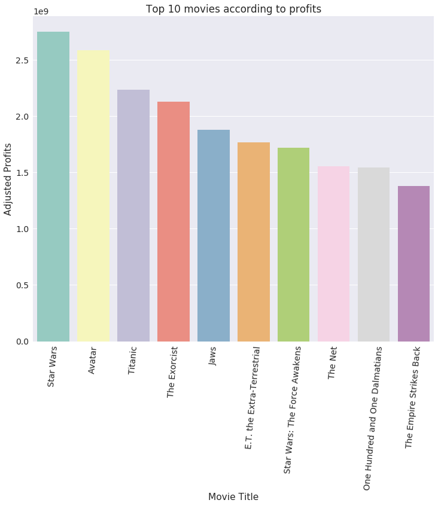

```python
# Now let's plot the top movies according to profits made
sns.set(rc={'figure.figsize':(12,10)}, font_scale=1.4)
tm = sns.barplot(prof.original_title, prof.profit_adj, palette="Set3")

# Rotate x-axis' text
for item in tm.get_xticklabels():
    item.set_rotation(85)

tm.set(xlabel='Movie Title', ylabel='Adjusted Profits', title = 'Top 10 movies according to profits')
plt.show()
```

```python
# Let's grab top 10 movies by revenue:
cd.sort_values("revenue_adj",axis=0,ascending=False,inplace=True)
```

```python
rev = cd.iloc[:10]
```

```python
rev.head()
```

|  | popularity | original_title | cast | runtime | genres | release_date | vote_count | vote_average | budget_adj | revenue_adj | profit_adj |
| --- | --- | --- | --- | --- | --- | --- | --- | --- | --- | --- | --- |
| 1386 | 9.432768 | Avatar | Sam Worthington\|Zoe Saldana\|Sigourney Weaver\|S... | 162 | Action\|Adventure\|Fantasy\|Science Fiction | 2009-12-10 | 8458 | 7.1 | 240886902 | 2827123750 | 2586236848 |
| 1329 | 12.037933 | Star Wars | Mark Hamill\|Harrison Ford\|Carrie Fisher\|Peter ... | 121 | Adventure\|Action\|Science Fiction | 1977-03-20 | 4428 | 7.9 | 39575591 | 2789712242 | 2750136651 |
| 5231 | 4.355219 | Titanic | Kate Winslet\|Leonardo DiCaprio\|Frances Fisher\|... | 194 | Drama\|Romance\|Thriller | 1997-11-18 | 4654 | 7.3 | 271692064 | 2506405735 | 2234713671 |
| 10594 | 2.010733 | The Exorcist | Linda Blair\|Max von Sydow\|Ellen Burstyn\|Jason ... | 122 | Drama\|Horror\|Thriller | 1973-12-26 | 1113 | 7.2 | 39289276 | 2167324901 | 2128035625 |
| 9806 | 2.563191 | Jaws | Roy Scheider\|Robert Shaw\|Richard Dreyfuss\|Lorr... | 124 | Horror\|Thriller\|Adventure | 1975-06-18 | 1415 | 7.3 | 28362748 | 1907005841 | 1878643093 |

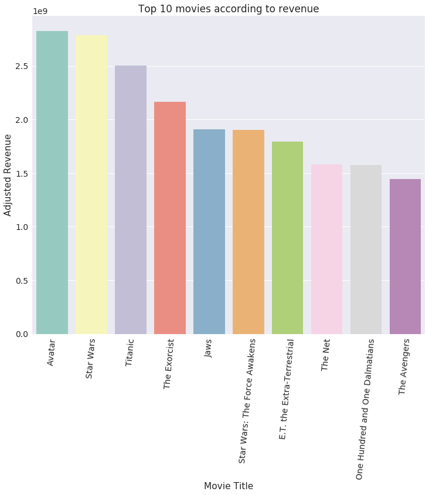

```python
# Now let's plot the top movies according to revenues made
sns.set(rc={'figure.figsize':(12,10)}, font_scale=1.4)
tr = sns.barplot(rev.original_title, rev.revenue_adj, palette="Set3")

# Rotate x-axis' text
for item in tr.get_xticklabels():
    item.set_rotation(85)

tr.set(xlabel='Movie Title', ylabel='Adjusted Revenue', title = 'Top 10 movies according to revenue')
plt.show()
```

> The above plots suggests that the top grossing movies in revenue aren't doesn't give the same indication about profit. Movies can make more profit while having less revenue or vice versa.

### The number of movies in each genres and the least popular?

```python
# This function which will take any column as argument from which data is to be extracted and keep track of the count
def extract_data(col):
    # This should take a column, and separate the string by '|'
    extracted = cd[col].str.cat(sep = '|')

    # Returning pandas series and storing the values separately
    extracted = pd.Series(extracted.split('|'))

    # Sorting values in descending order
    count = extracted.value_counts(ascending = False)

    return count
```

```python
# Let's check the genre that has the largest number of movies and the least
genre_count = extract_data('genres')
```

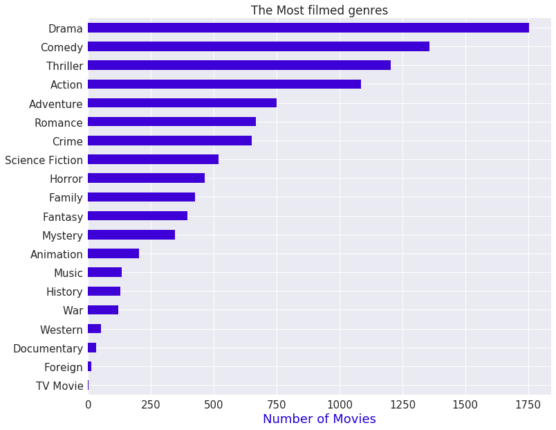

```python
# We want to plot in descending order from top to bottom

genre_count.sort_values(ascending = True, inplace = True)

# Initializing plot
i = genre_count.plot.barh(color = '#3d00d7', fontsize = 15)

# Title
i.set(title = 'The Most filmed genres')

# X-label
i.set_xlabel('Number of Movies', color = '#2000d7', fontsize = '18')

# Figure size(width, height)
i.figure.set_size_inches(12, 10)

# Shwoing the plot
plt.show()
```

> This shows the top genres by movie count and showing that by far, the top genre is Drama then comedy and that the least popular is TV Movie genre. This agrees with psycology of humans, that we like and are curious about stories and Drama seems to spice up stories to grab attention and that seems to be the most sought after genre.

### Most successful actors!

```python
# There are 2 ways to answer this question:
    # > the most sought after actors who starred in more movies than others
    # > The number of successful movies actors participated in from the top 10 most profitable movies
# We will first modify our earlier function:
def extract_prof(col):
    # This should take a column, and separate the string by '|'
    ext_prof = prof[col].str.cat(sep = '|')

    # Returning pandas series and storing the values separately
    ext_prof = pd.Series(ext_prof.split('|'))

    # Sorting values in descending order
    count = ext_prof.value_counts(ascending = False)

    return count
```

```python
# then we will go about using the new edited function to get our data
extract_prof('cast')
```

```
Harrison Ford         3
Carrie Fisher         3
Mark Hamill           3
Henry Thomas          1
Linda Blair           1
Sam Worthington       1
Peter Cushing         1
Zoe Saldana           1
J. Pat O'Malley       1
Sigourney Weaver      1
Robert Shaw           1
Alec Guinness         1
Anthony Daniels       1
Lorraine Gary         1
Peter Coyote          1
Wendy Gazelle         1
Sandra Bullock        1
Billy Dee Williams    1
Drew Barrymore        1
Jason Miller          1
Betty Lou Gerson      1
Robert MacNaughton    1
Max von Sydow         1
Ken Howard            1
Martha Wentworth      1
Kathy Bates           1
Lee J. Cobb           1
Murray Hamilton       1
Adam Driver           1
Ben Wright            1
Roy Scheider          1
Dennis Miller         1
Michelle Rodriguez    1
Kate Winslet          1
Jeremy Northam        1
Leonardo DiCaprio     1
Richard Dreyfuss      1
Ellen Burstyn         1
Billy Zane            1
Rod Taylor            1
Daisy Ridley          1
Frances Fisher        1
Dee Wallace           1
Stephen Lang          1
dtype: int64
```

> This is very interesting! from the top 10 profitable movies only 3 actors starred in 3 of the most successful movies

```python
extract_data('cast')
```

```
Robert De Niro           52
Bruce Willis             46
Samuel L. Jackson        44
Nicolas Cage             43
Matt Damon               36
Johnny Depp              35
Brad Pitt                34
Sylvester Stallone       34
Morgan Freeman           34
Harrison Ford            34
Tom Hanks                34
Tom Cruise               33
Denzel Washington        32
Eddie Murphy             32
Liam Neeson              31
Julianne Moore           30
Owen Wilson              30
Arnold Schwarzenegger    29
Meryl Streep             29
Mark Wahlberg            29
Gene Hackman             29
Willem Dafoe             29
Robin Williams           29
Ben Affleck              28
Jim Carrey               28
Ewan McGregor            28
Cameron Diaz             28
Dennis Quaid             28
Keanu Reeves             28
Colin Farrell            27
                         ..
Dominique Dunne           1
Nani                      1
Nichole Hiltz             1
Lorraine Nicholson        1
MÃ¤dchen Amick            1
Lyndon Smith              1
John Lennon               1
Derek Richardson          1
Little Richard            1
Bruce Way                 1
Laura Johnson             1
Kyle Secor                1
Casey Gooden              1
Barbara Gordon            1
Michelle Hurst            1
Jenna Boyd                1
Augustus Prew             1
Tony D'Amario             1
Lisa Barbuscia            1
Onata Aprile              1
Hanna Brown               1
Inger Stevens             1
Seth Meyers               1
John Randolph             1
James Blackwell           1
Dominique Swain           1
Lew Ayres                 1
Michael Hordern           1
DJ Pooh                   1
Ed Begley Jr.             1
Length: 6838, dtype: int64
```

> This provides a broader picture of actors and the number of movies they starred in. There are a lot of well known stars who made very successful movies.

### Which month takes the cake regarding number of movies made across all the years.

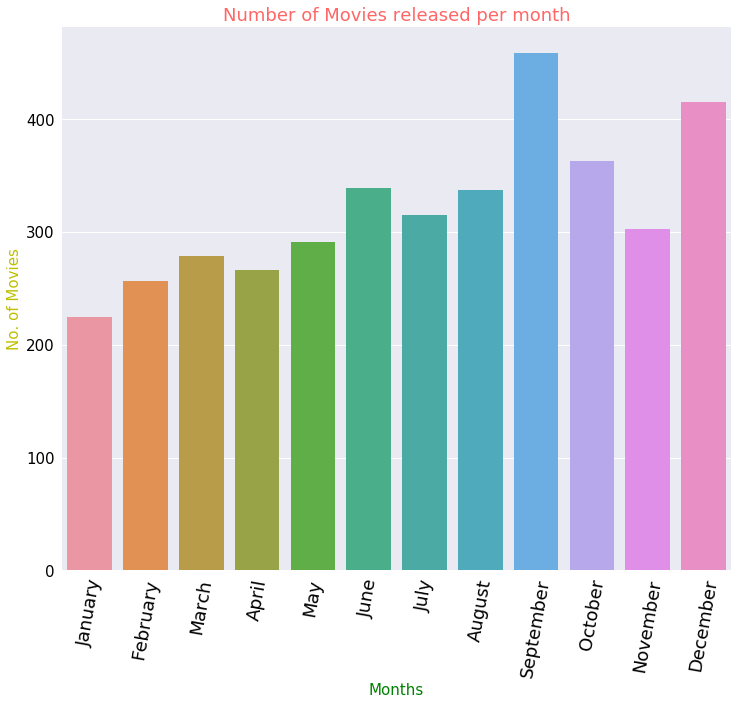

```python
# To answer this question we need to group by month.
# We will also calculate the profits for these months for next question
# We are going to create a new dataframe which has 'release-date' asthe index
index_release_date = cd.set_index('release_date')

# Group by month
groupby_index = index_release_date.groupby([(index_release_date.index.month)])

# Number of movies/month
m_movie_count = groupby_index['profit_adj'].count()

# Converting table to a dataframe
m_movie_count= pd.DataFrame(m_movie_count)

# Creating a list of months
m_list = ['January', 'February', 'March', 'April', 'May', 'June', 'July', 'August', 'September', 'October', 'November', 'December']

m_movie_count_bar = sns.barplot(x = m_movie_count.index, y = m_movie_count['profit_adj'], data = m_movie_count)

# Figure Size
m_movie_count_bar.figure.set_size_inches(12,10)

# Title
m_movie_count_bar.axes.set_title('Number of Movies released per month', color="r", fontsize = 18, alpha = 0.6)

# X-label
m_movie_count_bar.set_xlabel("Months", color="g", fontsize = 15)

# Y-label
m_movie_count_bar.set_ylabel("No. of Movies", color="y", fontsize = 15)

# Customizations
m_movie_count_bar.tick_params(labelsize = 15, labelcolor="black")

# Rotating the x-axis text
m_movie_count_bar.set_xticklabels(m_list, rotation = 80, size = 18)

# Show the plot
plt.show()
```

> This graph suggests that September and December are the most popular months for releasing movies and January has the least number of movies released

### Which month are the most profits made.

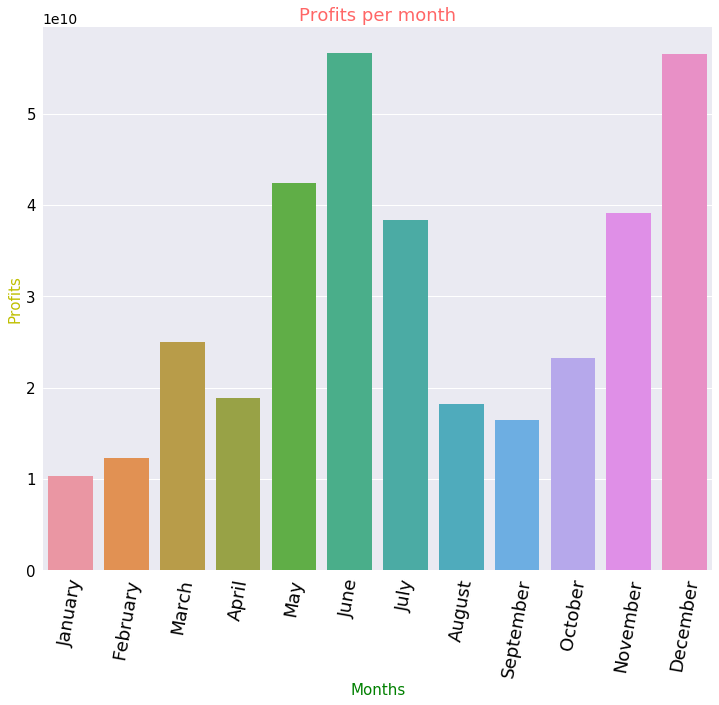

```python
# Since the data is grouped by month, we add 'profit_adj' values to respective months, saving all this to a new var
m_profit = groupby_index['profit_adj'].sum()

# Converting table to a dataframe
m_profit = pd.DataFrame(m_profit)

# Assigning values
m_profit_bar = sns.barplot(x = m_profit.index, y = m_profit['profit_adj'], data = m_profit)

# figure size
m_profit_bar.figure.set_size_inches(12,10)

# Title
m_profit_bar.axes.set_title('Profits per month', color="r", fontsize = 18, alpha = 0.6)

# X-label
m_profit_bar.set_xlabel("Months", color="g", fontsize = 15)
# Y-label
m_profit_bar.set_ylabel("Profits", color="y", fontsize = 15)

# Customizations
m_profit_bar.tick_params(labelsize = 15, labelcolor="black")

# Rotating the x-axis text
m_profit_bar.set_xticklabels(m_list, rotation = 80, size = 18)

# Show the plot
plt.show()
```

> very curious! While a lot of movies are released in September, December and June seem to be the time when movies are more likely to make more profit!

## Conclusions

> This analysis seems to suggest the following:
> - The most profitable movie isn't always the most grossing in revenue.
> - Provides a glimpse into the most popular actors and the number of movies they starred in.
> - Drama, Comedy, Thriller and Action are the 4 top genres where movie count is concerned.
> - January has the least number of movies and the least profit according to our analysis of this dataset
> - December seems to score in both, number of movies and profits gained.
> - While September has more movies released, the profits seems to be too low by comparison. I hope these tentative insights provide fuel for further analysis of this rich dataset.

```python
from subprocess import call
call(['python', '-m', 'nbconvert', 'Investigate_a_Dataset.ipynb'])
```

```
0
```